# Act Report: Short Twitter Data Analysis

### Tweet Data Insights

```python
import pandas as pd
from IPython.display import Image

tweets_master = pd.read_csv('twitter_archive_master.csv')
```

### Insights and Visualization

Looking at the clean data set, we can see that about 79% of the tweets in this data set have valid ratings using a scale of having a rating at least of 10 because 'every dog is a good boy' and capping values to 19 so that we don't hyper inflate the mean with invalid values such as '420' or '1776'.

```python
# How many tweets have valid ratings
1 - (tweets_master.rating_numerator.isnull().sum()/(len(tweets_master.rating_numerator)))
```

```
0.7879396984924623
```

#### Retweets and pups

```python
# Average number of retweets
tweets_master.retweet_count.mean()
```

```
2630.218090452261
```

#### Average ratings

```python
# tweet average dog rating
tweets_master.rating_numerator.mean()
```

[output not shown]

#### Visualize Average Ratings

I plotted the average rating that a dog receives on WeRateDogs. See histogram in the code. It represents a normal distribution but is skewed right with 12 as the most common value and 13, 14, 15 having a lower frequency than 10, 11, 12.

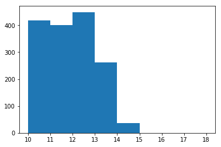

```python
# import visualization modules
import matplotlib.pyplot as plt
%matplotlib inline

plt.hist(tweets_master.rating_numerator, bins=[10, 11, 12, 13, 14, 15, 16, 17, 18]);
```

### Newfoundland Dogs

My favorite breed of dog is Newfoundland. People normally like dogs that resemble them and I'm no eception on this. Newfoundland dogs are big, have dark thick hair, and are good swimmers. Most people aren't familiar with this breed so lets take a look at one.

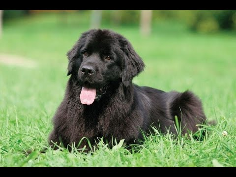

```python
# let me introduce you to my favorite dog breed, Newfoundland
Image(filename='newfoundland.jpg', width=300, height=300)
```

Lets see how well Newfoundland dogs are rated.

```python
# average rating for newfoundland, my favorite dog breed
my_favorite = tweets_master.query("p1 == 'Newfoundland'")
my_favorite.rating_numerator.mean()
```

```
11.0
```

Perhaps there's an odd skew so lets see the distribution of ratings.

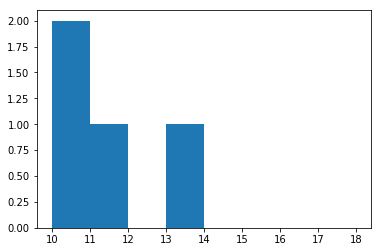

```python
# plot for newfoundland
plt.hist(my_favorite.rating_numerator, bins=[10, 11, 12, 13, 14, 15, 16, 17, 18]);
```

### Chihuahuas

Now lets look at my least favorite breed of dog, Chihuahuas. Hard for me to love but someone out there will.

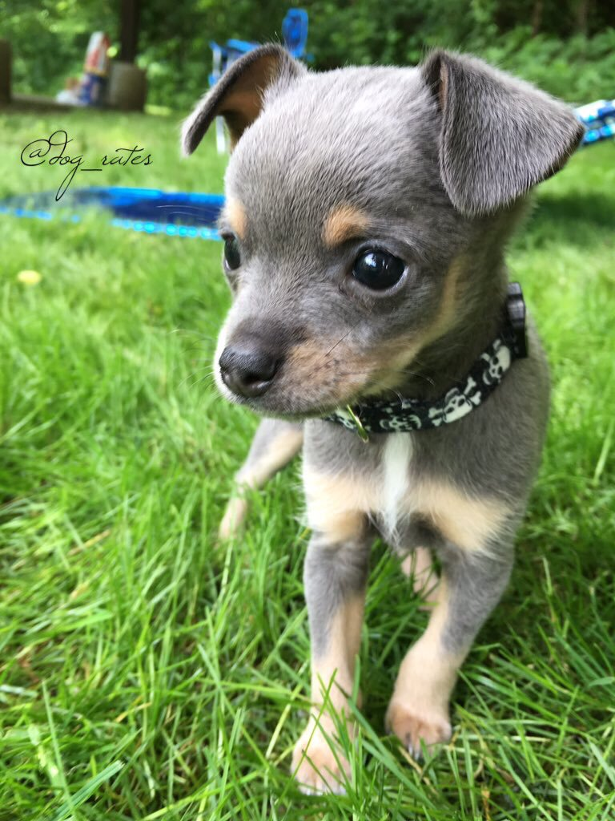

```python
# dataset only with least favorite dog breed
least_favorite = tweets_master.query("p1 == 'Chihuahua'")
# picutre of a chihuahua
Image(filename='chihuahua.jpg', width=300, height=300)
```

Lets see how Chihuahuas generally rate compared to Newfoundland

```python
# average rating for my least favorite, Chihuahua
least_favorite.rating_numerator.mean()
```

```
11.476190476190476
```

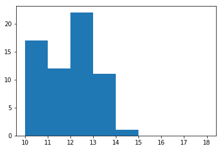

```python
# plot for chihuahua
plt.hist(least_favorite.rating_numerator, bins=[10, 11, 12, 13, 14, 15, 16, 17, 18]);
```

### Doggo vs Pupper

Finally, just to make sure there's no discrimination going on for large/mid sized dogs vs smaller dogs, lets look at doggos vs puppers.

```python
# average rating for mid size dogs and smaller dogs, doggo vs pupper
print ("The average rating for a doggo is", tweets_master.query("stage == 'doggo'").rating_numerator.mean())
print ("The average rating for a pupper is", tweets_master.query("stage == 'pupper'").rating_numerator.mean())
```

```
The average rating for a doggo is 12.083333333333334
The average rating for a pupper is 11.274363636363637
```

### Conclusion

Overall, WeRateDogs is a feel good profile but they tend to be fairly consistent about their ratings. When a dog is present in the tweet, they will grade fairly and rarely use values higher than 13, only for the very good boys/girls.